# My Homework 4

Bin Liu

2023-10-06

# Importing data for Electric Vehicle Popultion Size History

```r
library(readr)
Electric_Vehicle_Population_Size_History <- read_csv("Fall 2023 - Business Forecasting/Datasets/Electric_Vehicle_Population_Size_History.csv")
View(Electric_Vehicle_Population_Size_History)
```

# Creating a time series for Electric Vehicle (EV) Total

```r
library(fpp)
library(fpp2)
```

```r
library(TTR)

Electric_Vehicle_Population_Total_ts <- ts(Electric_Vehicle_Population_Size_History$`Electric Vehicle (EV) Total`, frequency = 12, start = c(2017,1))
Electric_Vehicle_Population_Total_ts
```

```
##         Jan    Feb    Mar    Apr    May    Jun    Jul    Aug    Sep    Oct
## 2017  22425  23094  23688  24390  25066  25737  26310  26825  27452  28173
## 2018  30267  30809  31573  32438  33634  34790  35633  36540  37454  39159
## 2019  43837  44579  45068  46344  47305  48385  49630  50583  51581  53436
## 2020  57137  57731  58606  58910  58915  59277  60813  61558  62338  63610
## 2021  68130  69286  70467  72790  74437  76145  78598  80537  82064  84200
## 2022  89954  91856  93908  96667  98524 100720 103480 106249 108061 111690
## 2023 121935 124930 128097 132365 136579 140832 144810 150482
##         Nov    Dec
## 2017  28765  29305
## 2018  40801  42065
## 2019  54060  54883
## 2020  65142  66230
## 2021  86245  88027
## 2022 115343 118127
## 2023
```

```r
attributes (Electric_Vehicle_Population_Total_ts)
```

```
## $tsp
## [1] 2017.000 2023.583   12.000
##
## $class
## [1] "ts"
```

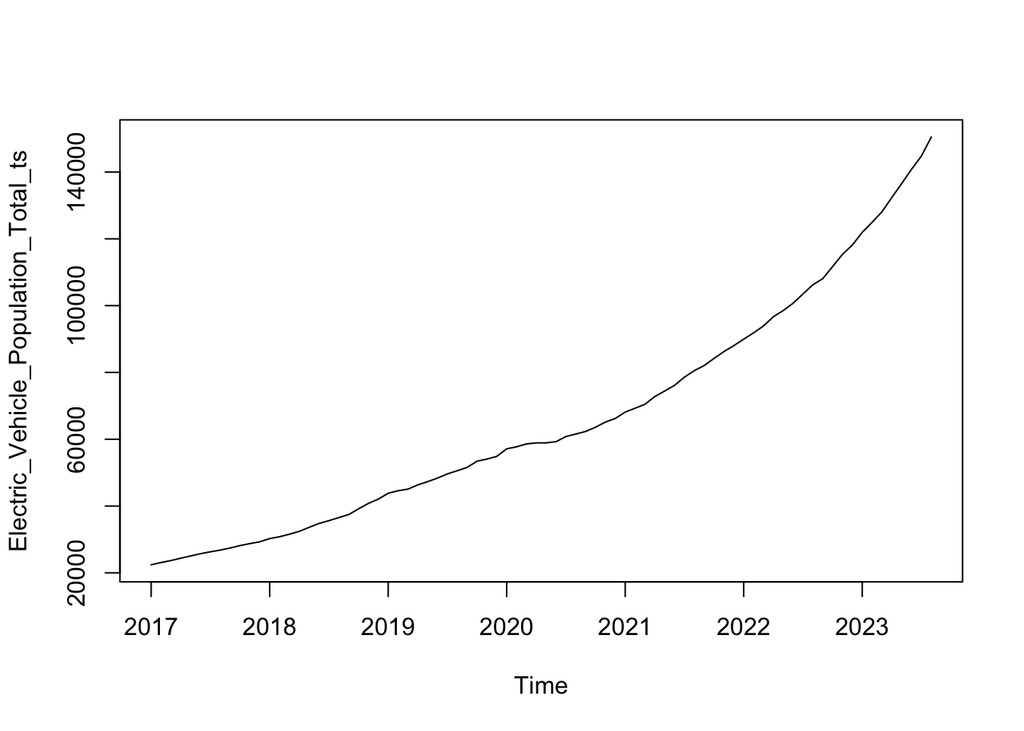

```r
plot(Electric_Vehicle_Population_Total_ts)
```

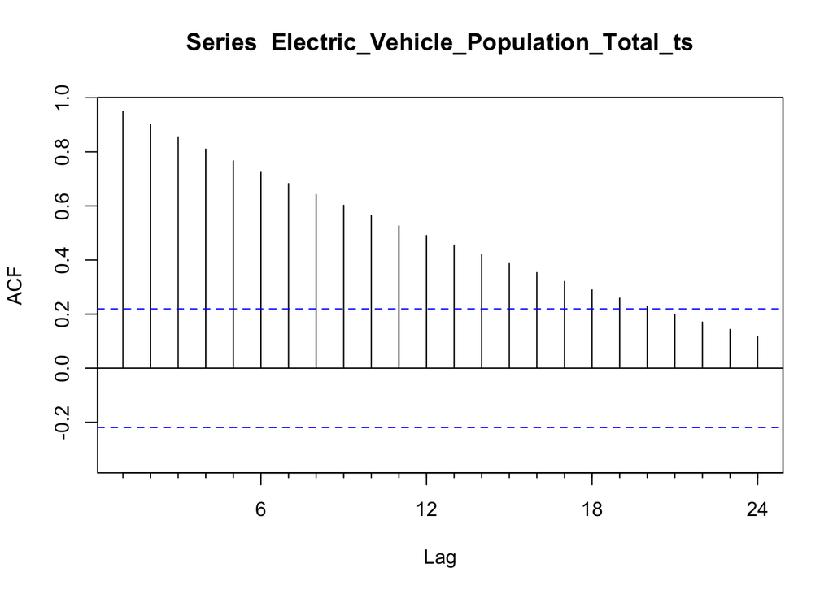

```r
Acf(Electric_Vehicle_Population_Total_ts)
```

# Forecasting Models

## Average Model

#### The Average Model takes the average of all historical points. The plot shows that the avearge of the total registration of electric vehicles in the State of Washington is 66,273.58. This model will take this average to forecast for the next 24 months, which is the blue straight line in the plot. The shaded area shows the confidence interval that the future values may lie between this area. As we can see from the plot, this is not a good forecasting model for this data based on the trend since the forecasted values are way below the current trend.

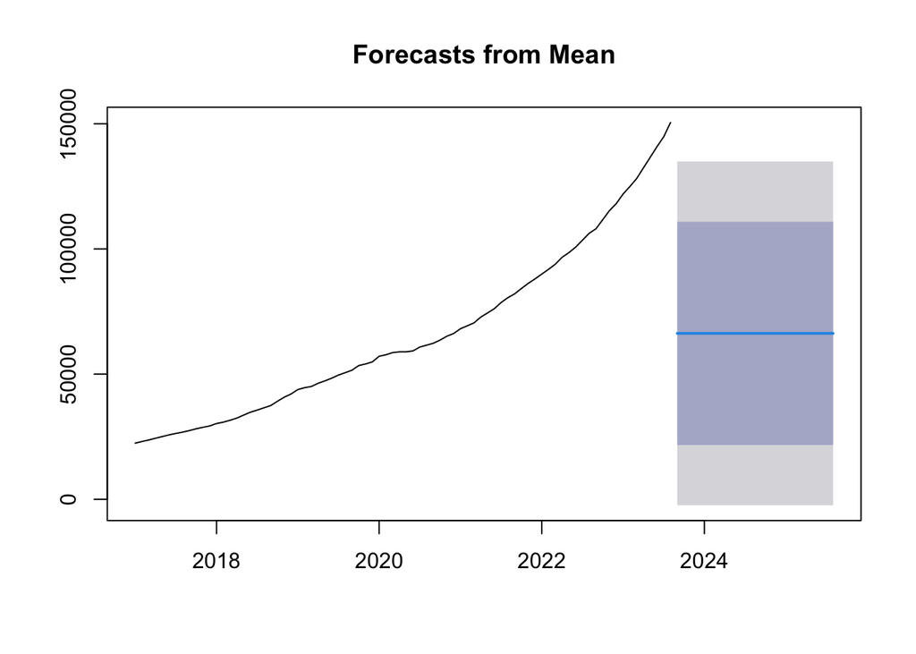

```r
mean_forecast <- meanf(Electric_Vehicle_Population_Total_ts, 24)
plot(mean_forecast)
```

```r
attributes(mean_forecast)
```

```
## $names
##  [1] "method"    "level"     "x"         "series"    "mean"      "lower"
##  [7] "upper"     "model"     "lambda"    "fitted"    "residuals"
##
## $class
## [1] "forecast"
```

```r
summary(mean_forecast)
```

```
##
## Forecast method: Mean
##
## Model Information:
## $mu
## [1] 66273.58
##
## $mu.se
## [1] 3832.713
##
## $sd
## [1] 34280.83
##
## $bootstrap
## [1] FALSE
##
## $call
## meanf(y = Electric_Vehicle_Population_Total_ts, h = 24)
##
## attr(,"class")
## [1] "meanf"
##
## Error measures:
##                        ME    RMSE      MAE       MPE     MAPE     MASE
## Training set 7.275958e-12 34065.9 28119.51 -31.24979 56.11059 1.564725
##                   ACF1
## Training set 0.9498006
##
## Forecasts:
##          Point Forecast    Lo 80    Hi 80     Lo 95  Hi 95
## Sep 2023       66273.58 21694.38 110852.8 -2385.846 134933
## Oct 2023       66273.58 21694.38 110852.8 -2385.846 134933
## Nov 2023       66273.58 21694.38 110852.8 -2385.846 134933
## Dec 2023       66273.58 21694.38 110852.8 -2385.846 134933
## Jan 2024       66273.58 21694.38 110852.8 -2385.846 134933
## Feb 2024       66273.58 21694.38 110852.8 -2385.846 134933
## Mar 2024       66273.58 21694.38 110852.8 -2385.846 134933
## Apr 2024       66273.58 21694.38 110852.8 -2385.846 134933
## May 2024       66273.58 21694.38 110852.8 -2385.846 134933
## Jun 2024       66273.58 21694.38 110852.8 -2385.846 134933
## Jul 2024       66273.58 21694.38 110852.8 -2385.846 134933
## Aug 2024       66273.58 21694.38 110852.8 -2385.846 134933
## Sep 2024       66273.58 21694.38 110852.8 -2385.846 134933
## Oct 2024       66273.58 21694.38 110852.8 -2385.846 134933
## Nov 2024       66273.58 21694.38 110852.8 -2385.846 134933
## Dec 2024       66273.58 21694.38 110852.8 -2385.846 134933
## Jan 2025       66273.58 21694.38 110852.8 -2385.846 134933
## Feb 2025       66273.58 21694.38 110852.8 -2385.846 134933
## Mar 2025       66273.58 21694.38 110852.8 -2385.846 134933
## Apr 2025       66273.58 21694.38 110852.8 -2385.846 134933
## May 2025       66273.58 21694.38 110852.8 -2385.846 134933
## Jun 2025       66273.58 21694.38 110852.8 -2385.846 134933
## Jul 2025       66273.58 21694.38 110852.8 -2385.846 134933
## Aug 2025       66273.58 21694.38 110852.8 -2385.846 134933
```

## Naive Model

#### The Naive Model takes the last month’s data to forecast for the next 24 months as shown in the blue straight line in the plot. The confidence interval shows the future values may lie within this shaded area based on this prediction. This forecasting model does not appear to be a good model based on the trend.

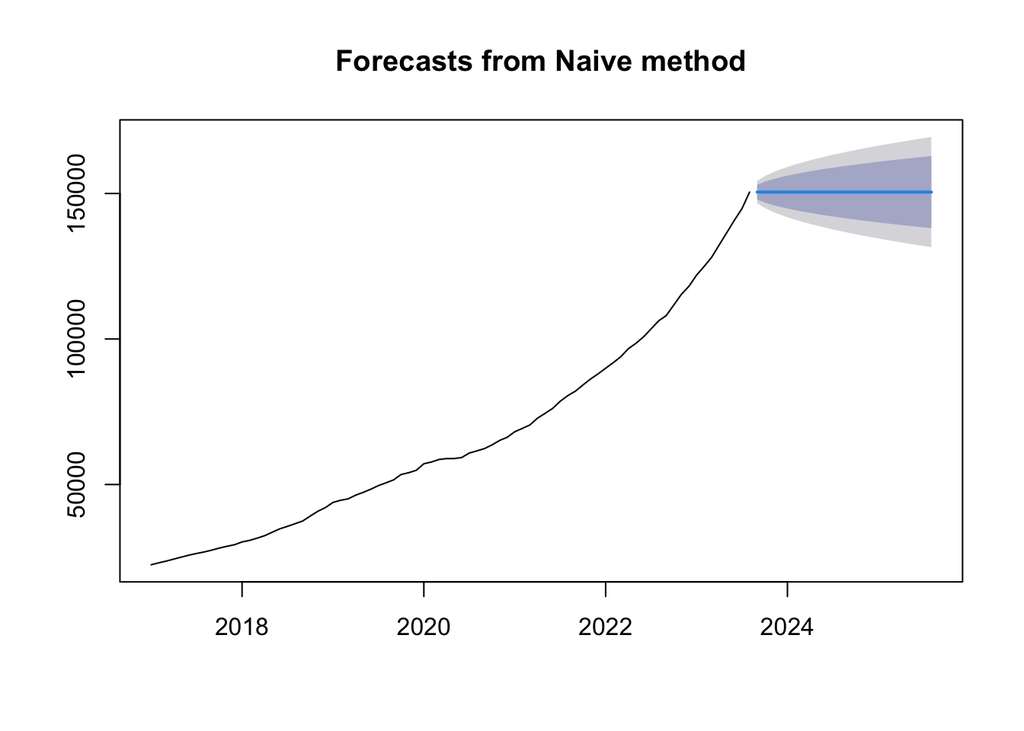

```r
naive_forecast <- naive(Electric_Vehicle_Population_Total_ts, 24)
plot(naive_forecast)
```

```r
summary(naive_forecast)
```

```
##
## Forecast method: Naive method
##
## Model Information:
## Call: naive(y = Electric_Vehicle_Population_Total_ts, h = 24)
##
## Residual sd: 1971.8019
##
## Error measures:
##                    ME     RMSE      MAE      MPE     MAPE       MASE      ACF1
## Training set 1620.975 1971.802 1620.975 2.377577 2.377577 0.09019999 0.7573396
##
## Forecasts:
##          Point Forecast    Lo 80    Hi 80    Lo 95    Hi 95
## Sep 2023         150482 147955.0 153009.0 146617.3 154346.7
## Oct 2023         150482 146908.3 154055.7 145016.5 155947.5
## Nov 2023         150482 146105.2 154858.8 143788.2 157175.8
## Dec 2023         150482 145428.1 155535.9 142752.7 158211.3
## Jan 2024         150482 144831.5 156132.5 141840.4 159123.6
## Feb 2024         150482 144292.2 156671.8 141015.6 159948.4
## Mar 2024         150482 143796.3 157167.7 140257.1 160706.9
## Apr 2024         150482 143334.7 157629.3 139551.1 161412.9
## May 2024         150482 142901.1 158062.9 138888.0 162076.0
## Jun 2024         150482 142491.0 158473.0 138260.9 162703.1
## Jul 2024         150482 142101.0 158863.0 137664.4 163299.6
## Aug 2024         150482 141728.3 159235.7 137094.4 163869.6
## Sep 2024         150482 141370.9 159593.1 136547.8 164416.2
## Oct 2024         150482 141027.0 159937.0 136021.8 164942.2
## Nov 2024         150482 140695.1 160268.9 135514.2 165449.8
## Dec 2024         150482 140374.1 160589.9 135023.4 165940.6
## Jan 2025         150482 140063.1 160900.9 134547.6 166416.4
## Feb 2025         150482 139761.0 161203.0 134085.6 166878.4
## Mar 2025         150482 139467.2 161496.8 133636.3 167327.7
## Apr 2025         150482 139181.1 161782.9 133198.7 167765.3
## May 2025         150482 138902.0 162062.0 132771.9 168192.1
## Jun 2025         150482 138629.5 162334.5 132355.1 168608.9
## Jul 2025         150482 138363.1 162600.9 131947.7 169016.3
## Aug 2025         150482 138102.4 162861.6 131549.1 169414.9
```

## Random Walk Forecast (RWF)

#### Similar to the Naive Model, the Random Walk Forecast Model also takes the last month’s data to forecast for the values in the next 24 months with the same values for the confidence interval. Again, it is not considered a good forecasting model based on the trend.

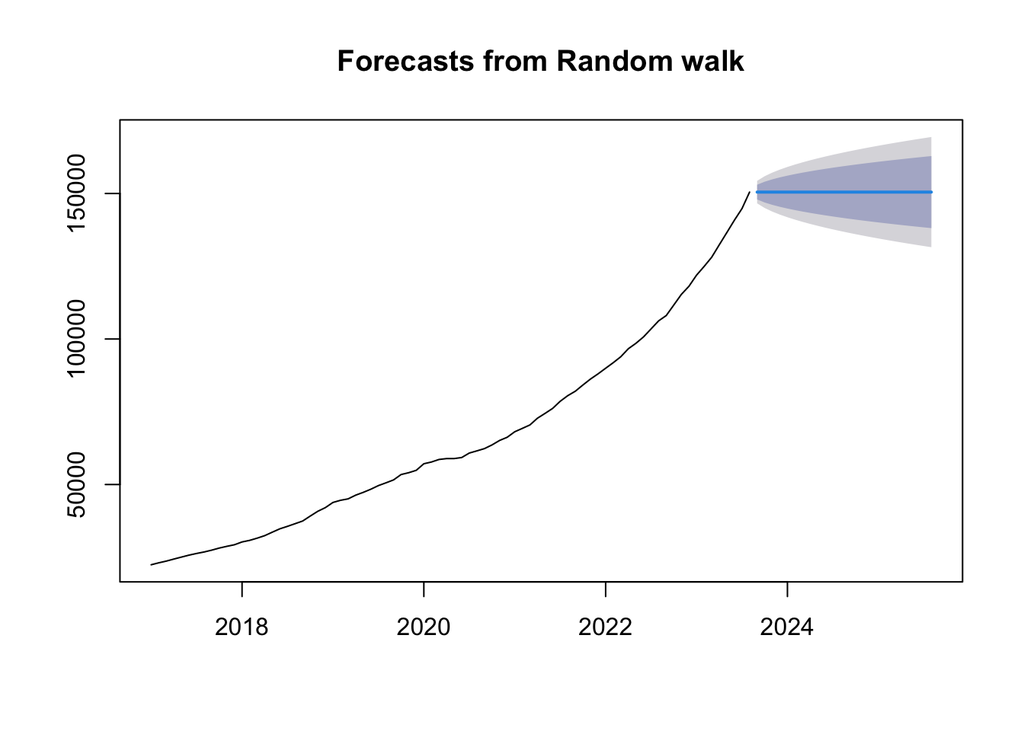

```r
rwf_forecast <- rwf(Electric_Vehicle_Population_Total_ts,24)
plot(rwf_forecast)
```

```r
summary(rwf_forecast)
```

```
##
## Forecast method: Random walk
##
## Model Information:
## Call: rwf(y = Electric_Vehicle_Population_Total_ts, h = 24)
##
## Residual sd: 1971.8019
##
## Error measures:
##                    ME     RMSE      MAE      MPE     MAPE       MASE      ACF1
## Training set 1620.975 1971.802 1620.975 2.377577 2.377577 0.09019999 0.7573396
##
## Forecasts:
##          Point Forecast    Lo 80    Hi 80    Lo 95    Hi 95
## Sep 2023         150482 147955.0 153009.0 146617.3 154346.7
## Oct 2023         150482 146908.3 154055.7 145016.5 155947.5
## Nov 2023         150482 146105.2 154858.8 143788.2 157175.8
## Dec 2023         150482 145428.1 155535.9 142752.7 158211.3
## Jan 2024         150482 144831.5 156132.5 141840.4 159123.6
## Feb 2024         150482 144292.2 156671.8 141015.6 159948.4
## Mar 2024         150482 143796.3 157167.7 140257.1 160706.9
## Apr 2024         150482 143334.7 157629.3 139551.1 161412.9
## May 2024         150482 142901.1 158062.9 138888.0 162076.0
## Jun 2024         150482 142491.0 158473.0 138260.9 162703.1
## Jul 2024         150482 142101.0 158863.0 137664.4 163299.6
## Aug 2024         150482 141728.3 159235.7 137094.4 163869.6
## Sep 2024         150482 141370.9 159593.1 136547.8 164416.2
## Oct 2024         150482 141027.0 159937.0 136021.8 164942.2
## Nov 2024         150482 140695.1 160268.9 135514.2 165449.8
## Dec 2024         150482 140374.1 160589.9 135023.4 165940.6
## Jan 2025         150482 140063.1 160900.9 134547.6 166416.4
## Feb 2025         150482 139761.0 161203.0 134085.6 166878.4
## Mar 2025         150482 139467.2 161496.8 133636.3 167327.7
## Apr 2025         150482 139181.1 161782.9 133198.7 167765.3
## May 2025         150482 138902.0 162062.0 132771.9 168192.1
## Jun 2025         150482 138629.5 162334.5 132355.1 168608.9
## Jul 2025         150482 138363.1 162600.9 131947.7 169016.3
## Aug 2025         150482 138102.4 162861.6 131549.1 169414.9
```

## A drift with RWF

#### The Random Walk Forecast Model with a drift shows an upward trend for the next 24 months. The confidence interval also has an increased values as opposed to the Random Walk Forecast Model. This shows a better forecast based on the trend of the time series.

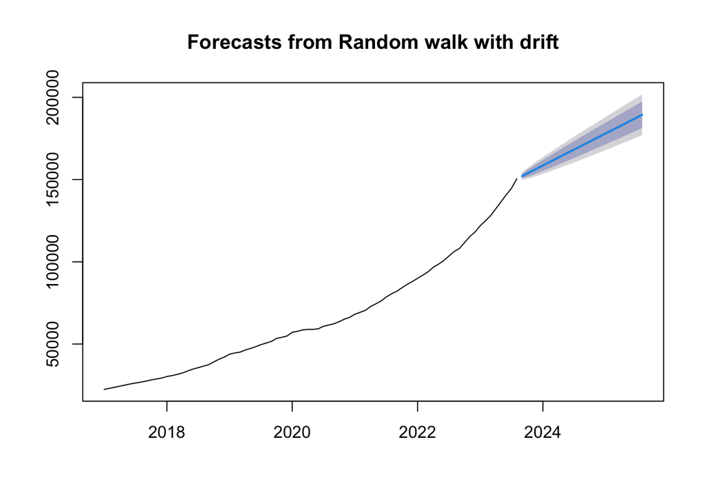

```r
rwf_forecast_drift <- rwf(Electric_Vehicle_Population_Total_ts,24, drift=TRUE)
plot(rwf_forecast_drift)
```

```r
summary(rwf_forecast_drift)
```

```
##
## Forecast method: Random walk with drift
##
## Model Information:
## Call: rwf(y = Electric_Vehicle_Population_Total_ts, h = 24, drift = TRUE)
##
## Drift: 1620.9747  (se 127.1202)
## Residual sd: 1129.8687
##
## Error measures:
##                         ME     RMSE      MAE        MPE     MAPE       MASE
## Training set -1.842015e-13 1122.695 873.4901 -0.7817773 1.556505 0.04860582
##                   ACF1
## Training set 0.7573396
##
## Forecasts:
##          Point Forecast    Lo 80    Hi 80    Lo 95    Hi 95
## Sep 2023       152103.0 150645.9 153560.1 149874.5 154331.4
## Oct 2023       153723.9 151650.4 155797.5 150552.8 156895.1
## Nov 2023       155344.9 152789.8 157900.1 151437.1 159252.7
## Dec 2023       156965.9 153997.5 159934.3 152426.2 161505.6
## Jan 2024       158586.9 155248.2 161925.6 153480.8 163692.9
## Feb 2024       160207.8 156528.8 163886.9 154581.2 165834.5
## Mar 2024       161828.8 157831.7 165826.0 155715.7 167941.9
## Apr 2024       163449.8 159151.9 167747.7 156876.7 170022.9
## May 2024       165070.8 160486.0 169655.5 158059.0 172082.5
## Jun 2024       166691.7 161831.6 171551.9 159258.9 174124.6
## Jul 2024       168312.7 163186.8 173438.6 160473.4 176152.1
## Aug 2024       169933.7 164550.2 175317.2 161700.4 178167.0
## Sep 2024       171554.7 165920.7 177188.7 162938.2 180171.1
## Oct 2024       173175.6 167297.3 179054.0 164185.5 182165.8
## Nov 2024       174796.6 168679.3 180913.9 165441.0 184152.2
## Dec 2024       176417.6 170066.2 182769.0 166703.9 186131.3
## Jan 2025       178038.6 171457.3 184619.9 167973.4 188103.8
## Feb 2025       179659.5 172852.3 186466.8 169248.7 190070.4
## Mar 2025       181280.5 174250.8 188310.3 170529.4 192031.6
## Apr 2025       182901.5 175652.4 190150.6 171815.0 193988.0
## May 2025       184522.5 177056.9 191988.0 173104.9 195940.0
## Jun 2025       186143.4 178464.1 193822.8 174398.9 197887.9
## Jul 2025       187764.4 179873.7 195655.1 175696.7 199832.2
## Aug 2025       189385.4 181285.6 197485.2 176997.8 201773.0
```

## Seasonal Naive

#### The time series shows an upward trend and does not show any seasonality trend. Therefore, the Seasnoal Naive Model is not a good model. Based on the plot, it appears that it takes the upward trend from the recent months then a downward trend, then a similar upward trend again to forecast the values for the next 24 months. This model does not represent the increasing upward trend of the time series.

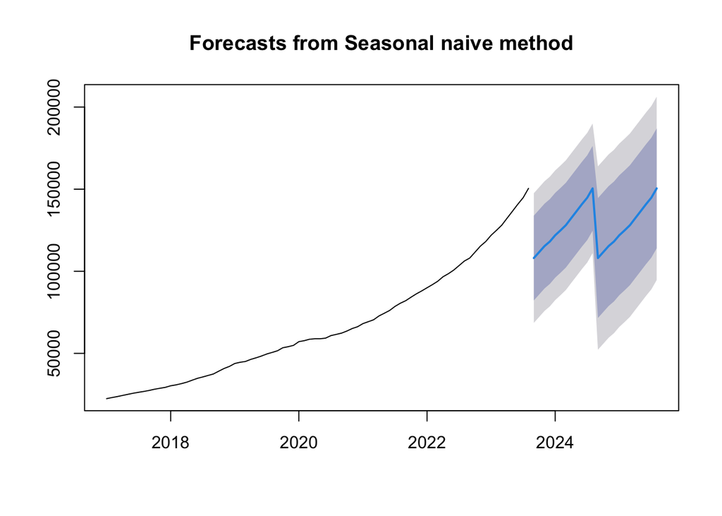

```r
snaive_forecast <- snaive(Electric_Vehicle_Population_Total_ts,24)
plot(snaive_forecast)
```

```r
summary(snaive_forecast)
```

```
##
## Forecast method: Seasonal naive method
##
## Model Information:
## Call: snaive(y = Electric_Vehicle_Population_Total_ts, h = 24)
##
## Residual sd: 20142.9651
##
## Error measures:
##                   ME     RMSE     MAE      MPE     MAPE MASE      ACF1
## Training set 17970.9 20142.97 17970.9 24.40798 24.40798    1 0.9243048
##
## Forecasts:
##          Point Forecast     Lo 80    Hi 80     Lo 95    Hi 95
## Sep 2023         108061  82246.75 133875.2  68581.51 147540.5
## Oct 2023         111690  85875.75 137504.2  72210.51 151169.5
## Nov 2023         115343  89528.75 141157.2  75863.51 154822.5
## Dec 2023         118127  92312.75 143941.2  78647.51 157606.5
## Jan 2024         121935  96120.75 147749.2  82455.51 161414.5
## Feb 2024         124930  99115.75 150744.2  85450.51 164409.5
## Mar 2024         128097 102282.75 153911.2  88617.51 167576.5
## Apr 2024         132365 106550.75 158179.2  92885.51 171844.5
## May 2024         136579 110764.75 162393.2  97099.51 176058.5
## Jun 2024         140832 115017.75 166646.2 101352.51 180311.5
## Jul 2024         144810 118995.75 170624.2 105330.51 184289.5
## Aug 2024         150482 124667.75 176296.2 111002.51 189961.5
## Sep 2024         108061  71554.14 144567.9  52228.58 163893.4
## Oct 2024         111690  75183.14 148196.9  55857.58 167522.4
## Nov 2024         115343  78836.14 151849.9  59510.58 171175.4
## Dec 2024         118127  81620.14 154633.9  62294.58 173959.4
## Jan 2025         121935  85428.14 158441.9  66102.58 177767.4
## Feb 2025         124930  88423.14 161436.9  69097.58 180762.4
## Mar 2025         128097  91590.14 164603.9  72264.58 183929.4
## Apr 2025         132365  95858.14 168871.9  76532.58 188197.4
## May 2025         136579 100072.14 173085.9  80746.58 192411.4
## Jun 2025         140832 104325.14 177338.9  84999.58 196664.4
## Jul 2025         144810 108303.14 181316.9  88977.58 200642.4
## Aug 2025         150482 113975.14 186988.9  94649.58 206314.4
```

## Moving Averages

### Moving average with order of 3

#### Based on the ACF, it shows that the recent data are more significant than the historical data. Therefore, the lower order moving average model provides a better forecast than higher order moving average model since the larger weight is given to the more recent period.

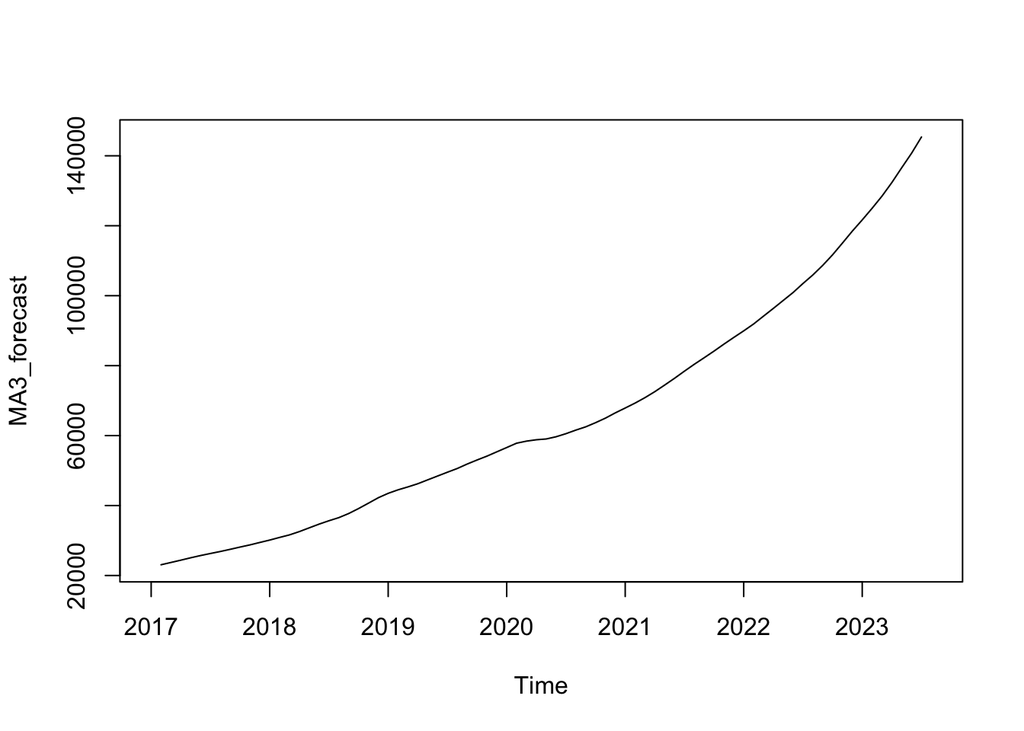

```r
MA3_forecast <- ma(Electric_Vehicle_Population_Total_ts,order=3)
plot(MA3_forecast)
```

### Moving average with order of 6

#### The moving average model with order of 6 still provides a good forecast for the upward trend although it smooths out the data more than the previous model with order of 3. It gives more weight to more historical data which appears to be less significant. This is not as good as the previous model with the lower order.

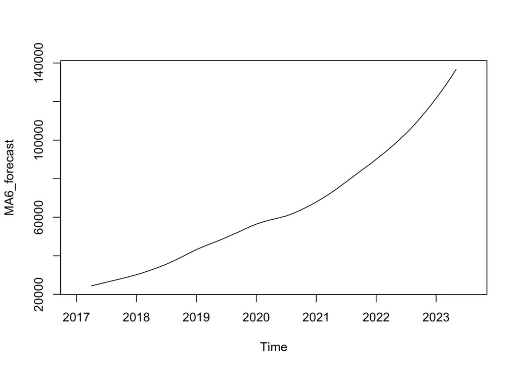

```r
MA6_forecast <- ma(Electric_Vehicle_Population_Total_ts,order=6)
plot(MA6_forecast)
```

### Moving average with order of 12

#### The larger order of the moving average model, the smoother effect on the plot. As we can see from the plot, it gives more weight to more historical data as comparing to the moving average model with order of 3 and 6. Therefore, it is not as good as the previous two models with the lower order.

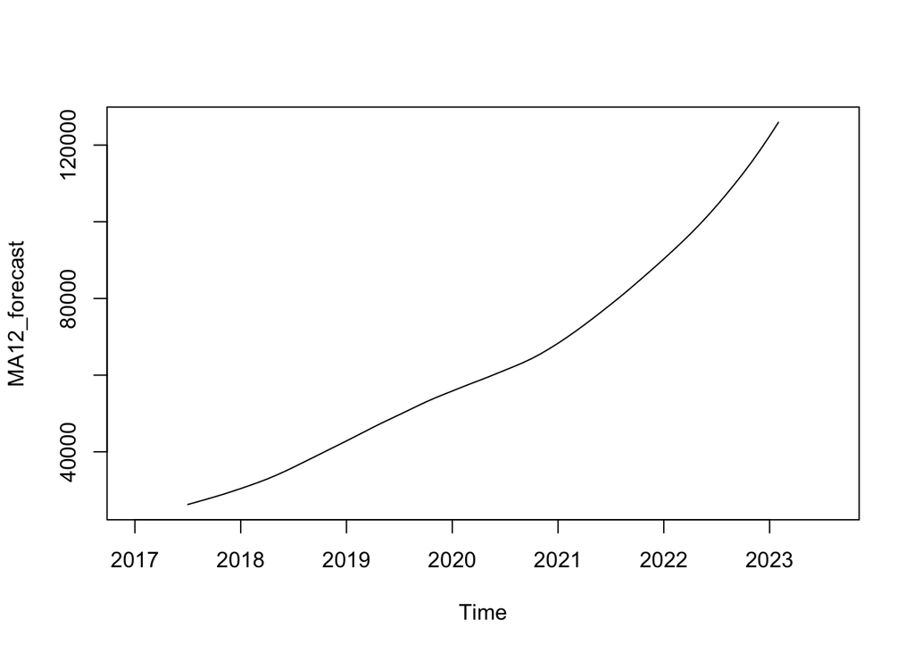

```r
MA12_forecast <- ma(Electric_Vehicle_Population_Total_ts,order=12)
plot(MA12_forecast)
```

### Moving average with order of 18

#### As mentioned above, the larger order of moving average puts more weight on more historical data. Therefore, the moving average with large order does not represent well for this time series.

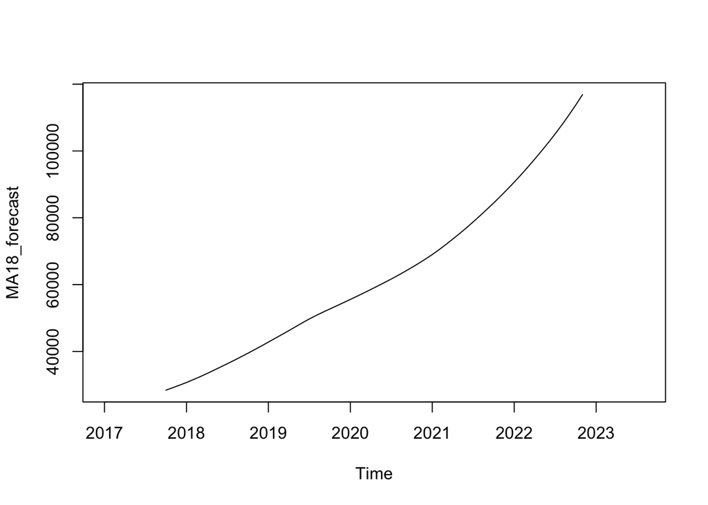

```r
MA18_forecast <- ma(Electric_Vehicle_Population_Total_ts,order=18)
plot(MA18_forecast)
```

## Holtwinters

#### The Holtwinters Model without any smoothing constants provides a pretty good fit to the original data plot. The residuls are very small based on the comparison of the actual and forecasted data (black line vs red line).

```r
HW_forecast <- HoltWinters(Electric_Vehicle_Population_Total_ts)
plot(HW_forecast)
attributes(HW_forecast)
```

```
## $names
## [1] "fitted"       "x"            "alpha"        "beta"         "gamma"
## [6] "coefficients" "seasonal"     "SSE"          "call"
##
## $class
## [1] "HoltWinters"
```

```r
summary(HW_forecast)
```

```
##              Length Class  Mode
## fitted       272    mts    numeric
## x             80    ts     numeric
## alpha          1    -none- numeric
## beta           1    -none- numeric
## gamma          1    -none- numeric
## coefficients  14    -none- numeric
## seasonal       1    -none- character
## SSE            1    -none- numeric
## call           2    -none- call
```

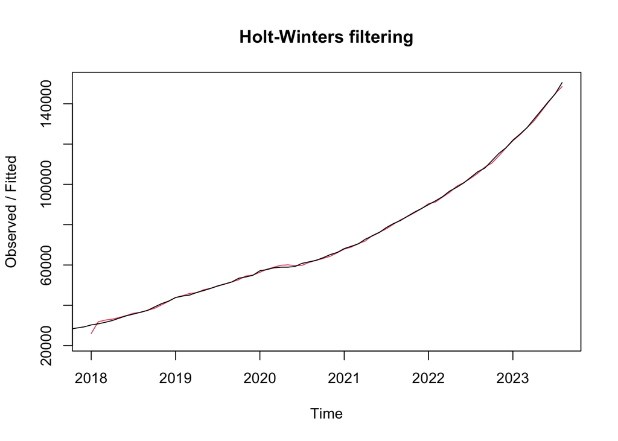

```r
plot(HW_forecast)
```

#### The Holtwinters Model with exponential smoothing for trend and non-seasonal model provides a decent fit. However, the residual are greater than the previous model with no smoothing constants.

```r
SSE_Simple <- HoltWinters(Electric_Vehicle_Population_Total_ts,beta=FALSE,gamma=FALSE)
attributes(SSE_Simple)
```

```
## $names
## [1] "fitted"       "x"            "alpha"        "beta"         "gamma"
## [6] "coefficients" "seasonal"     "SSE"          "call"
##
## $class
## [1] "HoltWinters"
```

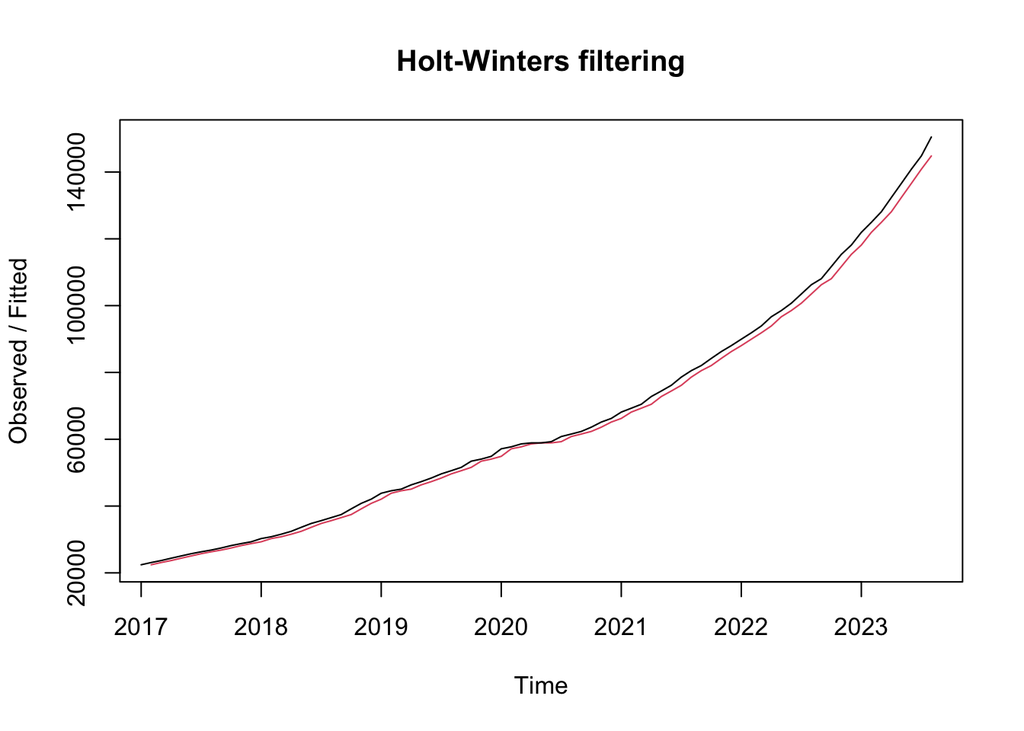

```r
plot(SSE_Simple)
```

```r
SSE_Simple$SSE
```

```
## [1] 307178580
```

```r
head(SSE_Simple$fitted)
```

```
##              xhat    level
## Feb 2017 22425.00 22425.00
## Mar 2017 23093.97 23093.97
## Apr 2017 23687.97 23687.97
## May 2017 24389.97 24389.97
## Jun 2017 25065.97 25065.97
## Jul 2017 25736.97 25736.97
```

#### The Holtwinters Model with non-exponential smoothing for trend and non-seasonal model provides a pretty nice fit and the residuals are small among the acutal and forecasted data.

```r
SSE_Simple_1 <- HoltWinters(Electric_Vehicle_Population_Total_ts,beta=TRUE,gamma=FALSE)
attributes(SSE_Simple_1)
```

```
## $names
## [1] "fitted"       "x"            "alpha"        "beta"         "gamma"
## [6] "coefficients" "seasonal"     "SSE"          "call"
##
## $class
## [1] "HoltWinters"
```

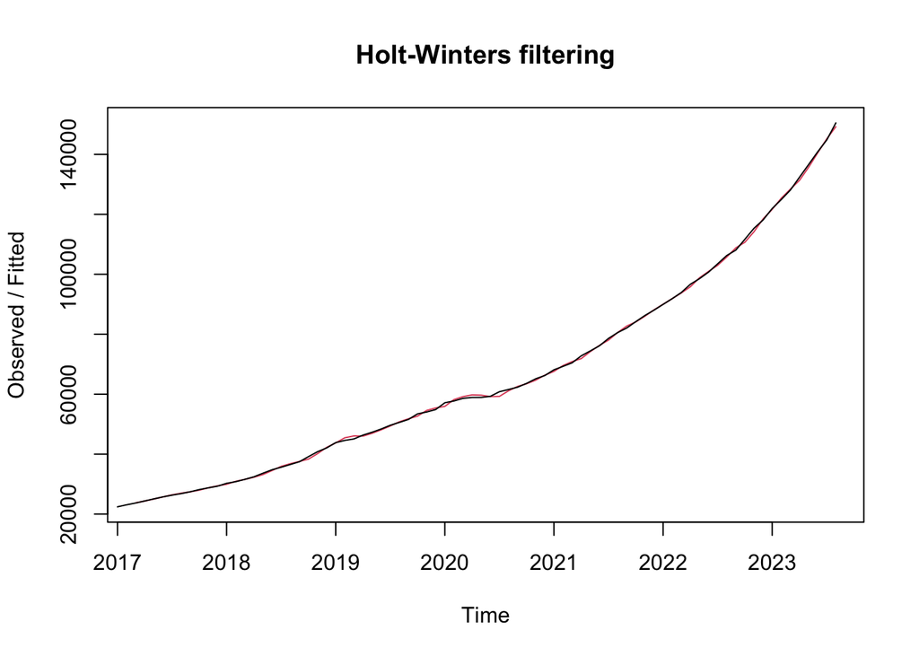

```r
plot(SSE_Simple_1)
```

```r
SSE_Simple_1$SSE
```

```
## [1] 22118991
```

```r
head(SSE_Simple_1$fitted)
```

```
##              xhat    level    trend
## Mar 2017 23763.00 23094.00 669.0000
## Apr 2017 24342.79 23718.40 624.3968
## May 2017 25023.34 24370.87 652.4709
## Jun 2017 25726.55 25048.71 677.8421
## Jul 2017 26416.82 25732.77 684.0557
## Aug 2017 26973.82 26353.29 620.5281
```

#### The Holtwinters Model with non-exponential smoothing for trend and seasonal model also provides a pretty nice fit and the residuals are small among the acutal and forecasted data.

```r
SSE_Simple_2 <- HoltWinters(Electric_Vehicle_Population_Total_ts,beta=TRUE,gamma=TRUE)
attributes(SSE_Simple_2)
```

```
## $names
## [1] "fitted"       "x"            "alpha"        "beta"         "gamma"
## [6] "coefficients" "seasonal"     "SSE"          "call"
##
## $class
## [1] "HoltWinters"
```

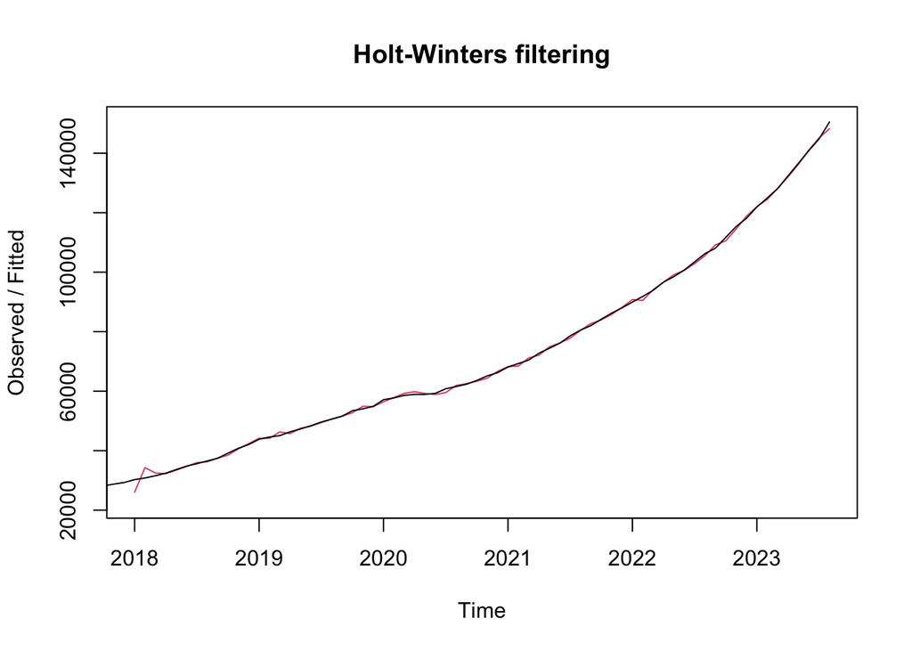

```r
plot(SSE_Simple_2)
```

```r
SSE_Simple_2$SSE
```

```
## [1] 56839993
```

```r
head(SSE_Simple_2$fitted)
```

```
##              xhat    level     trend     season
## Jan 2018 26034.51 25199.69  775.1234   59.69792
## Feb 2018 34283.26 29837.25 4637.5633 -191.55208
## Mar 2018 32522.28 31304.31 1467.0597 -249.09375
## Apr 2018 32247.28 31905.09  600.7795 -258.59375
## May 2018 33432.90 32679.92  774.8285  -21.84375
## Jun 2018 34697.59 33638.26  958.3431  100.98958
```

#### The Holtwinters Model with exponential smoothing for trend and seasonal model provides quite similar forecast with the exponential smoothing for trend and non-seaonal model. In both models, the residuals are greater than the other Holtwinters models displayed above.

```r
SSE_Simple_3 <- HoltWinters(Electric_Vehicle_Population_Total_ts,beta=FALSE,gamma=TRUE)
attributes(SSE_Simple_3)
```

```
## $names
## [1] "fitted"       "x"            "alpha"        "beta"         "gamma"
## [6] "coefficients" "seasonal"     "SSE"          "call"
##
## $class
## [1] "HoltWinters"
```

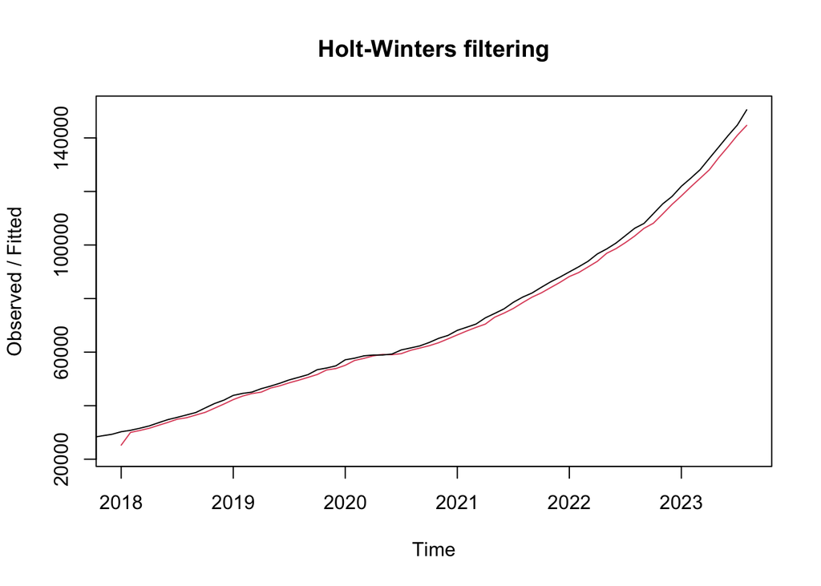

```r
plot(SSE_Simple_3)
```

```r
SSE_Simple_3$SSE
```

```
## [1] 325250864
```

```r
head(SSE_Simple_2$fitted)
```

```
##              xhat    level     trend     season
## Jan 2018 26034.51 25199.69  775.1234   59.69792
## Feb 2018 34283.26 29837.25 4637.5633 -191.55208
## Mar 2018 32522.28 31304.31 1467.0597 -249.09375
## Apr 2018 32247.28 31905.09  600.7795 -258.59375
## May 2018 33432.90 32679.92  774.8285  -21.84375
## Jun 2018 34697.59 33638.26  958.3431  100.98958
```

# Plot all in a single chart

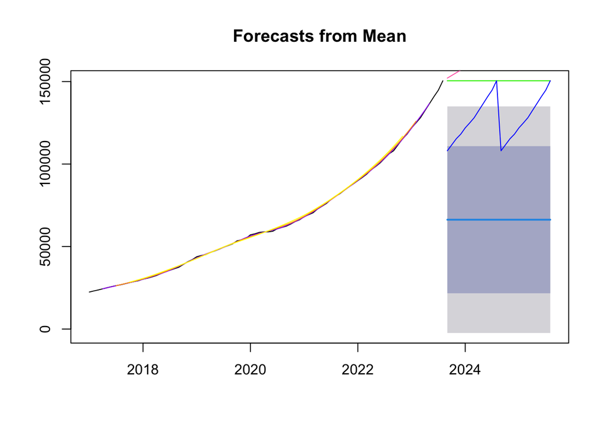

```r
plot(mean_forecast, col="black")
lines(naive_forecast$mean,col="red")
lines(rwf_forecast$mean, col="green")
lines(rwf_forecast_drift$mean, col="hotpink")
lines(snaive_forecast$mean, col="blue")
lines(MA6_forecast, col="purple")
lines(MA12_forecast, col="orange")
lines(MA18_forecast, col="yellow")
```

# Decomposition

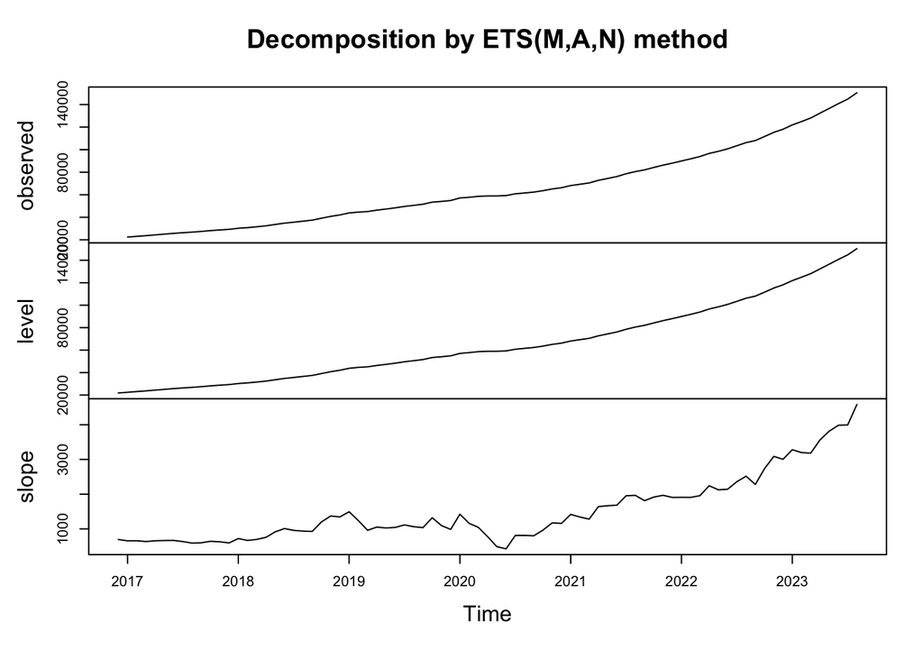

```r
ets_forecast <- ets(Electric_Vehicle_Population_Total_ts)
plot(ets_forecast)
```

```r
attributes(ets_forecast)
```

```
## $names
##  [1] "loglik"     "aic"        "bic"        "aicc"       "mse"
##  [6] "amse"       "fit"        "residuals"  "fitted"     "states"
## [11] "par"        "m"          "method"     "series"     "components"
## [16] "call"       "initstate"  "sigma2"     "x"
##
## $class
## [1] "ets"
```

```r
ets_forecast$mse
```

```
## [1] 275304.6
```

# Accuracy measures for different forecasting models

#### I pick the Mean Absolute Percentage Error (MAPE) as the accuracy measure for this time series. By comparing the MAPE with different models listed below, the Moving Average with order of 3 shows the least MAPE. This indicates that the Moving Average with order of 3 is the best model based on the accuracy comparison.

```r
library(forecast)
```

## Average Model

```r
accuracy(mean_forecast)
```

```
##                        ME    RMSE      MAE       MPE     MAPE     MASE
## Training set 7.275958e-12 34065.9 28119.51 -31.24979 56.11059 1.564725
##                   ACF1
## Training set 0.9498006
```

## Naive Model

```r
accuracy(naive_forecast)
```

```
##                    ME     RMSE      MAE      MPE     MAPE       MASE      ACF1
## Training set 1620.975 1971.802 1620.975 2.377577 2.377577 0.09019999 0.7573396
```

## Random Walk Forecast Model

```r
accuracy(rwf_forecast)
```

```
##                    ME     RMSE      MAE      MPE     MAPE       MASE      ACF1
## Training set 1620.975 1971.802 1620.975 2.377577 2.377577 0.09019999 0.7573396
```

## Random Walk Forecast with a Drift Model

```r
accuracy(rwf_forecast_drift)
```

```
##                         ME     RMSE      MAE        MPE     MAPE       MASE
## Training set -1.842015e-13 1122.695 873.4901 -0.7817773 1.556505 0.04860582
##                   ACF1
## Training set 0.7573396
```

## Seasonal Naive Model

```r
accuracy(snaive_forecast)
```

```
##                   ME     RMSE     MAE      MPE     MAPE MASE      ACF1
## Training set 17970.9 20142.97 17970.9 24.40798 24.40798    1 0.9243048
```

## Moving Averages with different orders (3, 6, 12 and 18)

```r
accuracy(MA3_forecast,Electric_Vehicle_Population_Total_ts, h=24)
```

```
##                 ME     RMSE     MAE         MPE      MAPE      ACF1 Theil's U
## Test set -21.38034 210.1715 150.765 -0.02526429 0.2403089 -0.414049 0.1283632
```

```r
accuracy(MA6_forecast,Electric_Vehicle_Population_Total_ts, h=24)
```

```
##                 ME     RMSE      MAE        MPE      MAPE      ACF1 Theil's U
## Test set -76.85473 308.7977 232.2872 -0.1015902 0.3866858 0.1726912 0.1968508
```

```r
accuracy(MA12_forecast,Electric_Vehicle_Population_Total_ts, h=24)
```

```
##                 ME     RMSE      MAE        MPE      MAPE      ACF1 Theil's U
## Test set -267.8989 575.2414 459.6562 -0.3930565 0.7614215 0.6495116 0.3453847
```

```r
accuracy(MA18_forecast,Electric_Vehicle_Population_Total_ts, h=24)
```

```
##                 ME     RMSE      MAE        MPE     MAPE      ACF1 Theil's U
## Test set -566.4534 997.2238 827.0959 -0.8592732 1.360718 0.8454964 0.5512701
```

## Holtwinters with different combinations of smoothing trends and seasonal models

```r
forecast_ets_hw <- forecast(HW_forecast, h=24)
accuracy(forecast_ets_hw)
```

```
##                    ME     RMSE     MAE       MPE      MAPE       MASE
## Training set 166.8618 774.4541 502.284 0.1987327 0.8978803 0.02794986
##                    ACF1
## Training set 0.00181798
```

```r
forecast_ets_SSE_Simple <- forecast(SSE_Simple, h=24)
accuracy(forecast_ets_SSE_Simple)
```

```
##                    ME     RMSE      MAE      MPE     MAPE       MASE      ACF1
## Training set 1621.049 1971.887 1621.049 2.377686 2.377686 0.09020412 0.7573582
```

```r
forecast_ets_SSE_Simple_1 <- forecast(SSE_Simple_1, h=24)
accuracy(forecast_ets_SSE_Simple_1)
```

```
##                    ME     RMSE      MAE       MPE      MAPE      MASE
## Training set 93.72343 532.5193 404.7442 0.1066907 0.6409175 0.0225222
##                    ACF1
## Training set 0.03504061
```

```r
forecast_ets_SSE_Simple_2 <- forecast(SSE_Simple_2, h=24)
accuracy(forecast_ets_SSE_Simple_2)
```

```
##                    ME    RMSE     MAE        MPE     MAPE       MASE       ACF1
## Training set 80.08842 914.266 590.824 0.08649111 1.079665 0.03287671 -0.3162797
```

```r
forecast_ets_SSE_Simple_3 <- forecast(SSE_Simple_3, h=24)
accuracy(forecast_ets_SSE_Simple_3)
```

```
##                   ME    RMSE      MAE      MPE     MAPE      MASE      ACF1
## Training set 1840.69 2187.03 1847.504 2.572231 2.583797 0.1028054 0.6318507
```